# Investigation of Model Systematic Errors

Joshua Williams

2025-12-02

**Goal**

Question: When all models predict incorrectly (systematic error), is it because of uncertain ground truth labels or because the model cannot extract the correct features needed to learn the scoring.

Why: Determining the source of the errors tells us what the next step in model development should be.

**Hypotheses**

Hypothesis 1: In cases of systematic error, the models will exhibit a high internal consensus, while the human scores exhibit variance (random voting at the boundary) and the model prediction will almost always be a near-miss.

Hypothesis 2: Systematic errors occur on images where visual cues are distinct to humans (high human agreement) but are consistently missed by models (models agree on the wrong score).

**Rationales**

Rationale 1: Human scoring of adjacent categories includes some randomness. If the nine models trained on different data splits agree on the same “incorrect” score, then it suggests the visual features for that class are mathematically stable, and the models have learned a consistent rule. The error is an artifact of the discrete labeling process, not a model failure.

Rationale 2: This might mean that the specific visual discriminator needed to push the classification from one score to another is lost in the 64x64 resolution. This could include relative scoring, where scorers annotations are influenced by other CDAs in the same image.

**Experimental Plan**

Define the following consensus metrics: 1. Human agreement: What proportion of the human scorers agreed with the ground truth median? 2. Model agreement: What proportion of the models predicted the median of the model predictions?

Define the following image subsets 1. Systematic error subset: Subset of images where 0 models predicted the human ground truth correctly. 2. Correct subset: Subset of images where >50% of models predicted the human ground truth correctly.

Test A: Determine if systematic errors occur significantly more when humans struggle to agree. - H0: The distribution of human agreement is identical between the systematic error subset and the correct subset. - Test: Mann-Whitney U Test (Wilcoxon Rank-Sum Test)

Test B: Determine if models are more internally consistent than humans on the disputed images. - H0: There is no difference in the variance of decision-making between models and humans within the systematic error subset. - Test: Wilcoxon Signed-Rank Test (Paired)

Validation of assumptions - ensure that the tests are appropriate. 1. Ensure images are distinct 2. Ensure human agreement and model agreement are ordinal 3. Generate histograms for human agreement in both subsets

```r
library(tidyverse)
df <- read_csv("/Users/jowillia/Documents/GitHub/AutoCDAScorer_Models/analyses/10_model_scoring_patterns/results_normalised.csv", show_col_types=FALSE)
df$experiment <- str_replace_all(df$experiment, "-", "_")
print(nrow(df))
```

```
## [1] 3052
```

### Note: Inductive Bias

The models are not entirely independent - the training/validation datasets were randomly sampled from the same original 6,336 images. There may therefore by chance be some overlap in training images between model pairs, but no two models saw exact training dataset.

Due to different architectures and augmentation types, this is likely to have a very minor effect on model agreement. It will not affect the selection of systematic error images, because the models trained on CGAN images have independent training data.

```r
# 1. Create the two main subsets
# Systematic Error: Where 0 models agreed with the human (agreement_p is 0)
sys_error_df <- df %>%
  filter(agreement_pct == 0)
print(nrow(sys_error_df))
```

```
## [1] 148
```

```r
# High Accuracy: Where more than 50% of models agreed with the human
high_agreement_df <- df %>%
  filter(agreement_pct > 0.5)
print(nrow(high_agreement_df))
```

```
## [1] 1948
```

```r
# 2. Create the further subset (removing ties)
# Filter the systematic error group to keep only rows where agreements differ
sys_error_no_ties <- sys_error_df %>%
  filter(human_agreement != model_agreement)
print(nrow(sys_error_no_ties))
```

```
## [1] 120
```

*Why remove ties?*

For Test B, we are asking “In cases where consistency differs, who is more consistent”. Cases where consistency doesn’t differ don’t help answer this question. Randomly assigning it would make the analysis non-reproducible unless I did some sort of Monte Carlo approach. The split / average method would inflate the sample size without actually adding information. By dropping the ties we make the test more conservative.

About 20% of the systematic error group have the same consistency between humans and models and were removed for Test B.

*Is the difference in sample size ok?*

For Test A, the imbalance is not a problem. The Mann-Whitney U test does not calculate averages, it calculates ranks. It is asking “Is a randomly selected value from Group A likely to be smaller than one from Group B”, accounting for size differences in its calculation. The small group is big enough to avoid statistical issues with imbalance.

```r
# Identify ties
ties_df <- sys_error_df %>%
  filter(human_agreement == model_agreement)

# Create a summary table counting 0s vs Non-0s
ties_breakdown <- ties_df %>%
  mutate(is_score_zero = ifelse(human_score == 0, "Score is 0", "Score is Non-Zero")) %>%
  count(is_score_zero)

# Calculate percentages
ties_breakdown <- ties_breakdown %>%
  mutate(percentage = n / sum(n) * 100)

print(ties_breakdown)
```

```
## # A tibble: 2 × 3
##   is_score_zero         n percentage
##   <chr>             <int>      <dbl>
## 1 Score is 0            3       10.7
## 2 Score is Non-Zero    25       89.3
```

```r
# View scores
table(ties_df$human_score)
```

```
##
## 0 1 2 3 4 5 6
## 3 3 3 4 7 5 3
```

I hypothesised that the cases where the model and human scoring consistencies were equal might all be 0s, because the models and humans might always agree on 0s. This is not the case.

```r
sys_error_breakdown <- sys_error_df %>%
  count(human_score) %>%
  mutate(percentage = n / sum(n) * 100) %>%
  arrange(human_score)

print(sys_error_breakdown)
```

```
## # A tibble: 7 × 3
##   human_score     n percentage
##         <dbl> <int>      <dbl>
## 1           0    11       7.43
## 2           1    14       9.46
## 3           2    24      16.2
## 4           3    31      20.9
## 5           4    33      22.3
## 6           5    19      12.8
## 7           6    16      10.8
```

It is more likely that images where all 9 models disagree with humans have intermediate ground truth values. This is interesting because it matches the known patterns of human agreement and model performance seen previously - intermediate phenotypes are more challenging to score.

## Test A: Determine if systematic errors occur significantly more when humans struggle to agree.

### Visualise distribution of human scoring consistency in the good and bad subsets

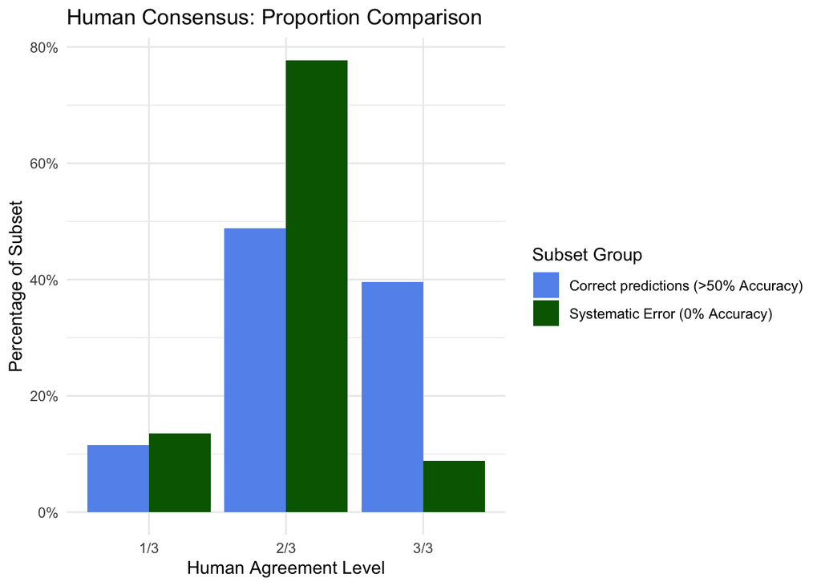

```r
sys_error_df$group_label <- "Systematic Error (0% Accuracy)"
high_agreement_df$group_label <- "Correct predictions (>50% Accuracy)"
plot_data <- bind_rows(sys_error_df, high_agreement_df)

ggplot(plot_data, aes(x = as.factor(human_agreement), group = group_label, fill = group_label)) +
geom_bar(aes(y = after_stat(prop)), position = "dodge") +
  scale_y_continuous(labels = scales::percent) +
  scale_x_discrete(labels = c("1/3", "2/3", "3/3")) +
  labs(title = "Human Consensus: Proportion Comparison",
       x = "Human Agreement Level",
       y = "Percentage of Subset",
       fill = "Subset Group") +
  theme_minimal() +
  scale_fill_manual(values = c("cornflowerblue", "darkgreen"))
```

This figure shows that in the systematic error group, the human scorers almost never fully agree - in nearly 80% of images two scorers agree, and one disagrees.

### Wilcoxon Rank-Sum Test

Due to the large dataset (~2100) images, I will choose an more stringent alpha value of 0.001.

```r
group_sys_error <- sys_error_df$human_agreement
group_correct <- high_agreement_df$human_agreement

# 'alternative = "less"' to test the specific hypothesis: "Is human agreement significantly LOWER in the systematic error group?"
test_result <- wilcox.test(x = group_sys_error,
                           y = group_correct,
                           alternative = "less")
print(test_result)
```

```
##
##  Wilcoxon rank sum test with continuity correction
##
## data:  group_sys_error and group_correct
## W = 103114, p-value = 7.42e-11
## alternative hypothesis: true location shift is less than 0
```

```r
# Check the means to confirm direction manually
cat("\nMean Human Agreement (Systematic Error Group):", mean(group_sys_error))
```

```
##
## Mean Human Agreement (Systematic Error Group): 0.6509009
```

```r
cat("\nMean Human Agreement (Correct Group):", mean(group_correct), "\n")
```

```
##
## Mean Human Agreement (Correct Group): 0.7602669
```

The Mann-Whitney U test shows that human agreement scores (scoring consistency) were significantly lower in the systematic error group (mean = 0.65) compared to the correct group (mean = 0.76), W=103,114, p<0.001.

## Test B: Determine if models are more internally consistent than humans on the disputed images.

### Visualise how often agreement is higher or lower amongst models than humans

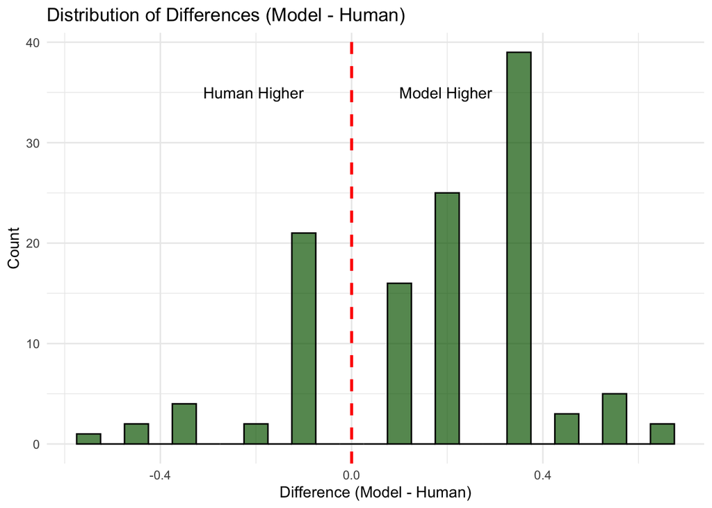

```r
# Calculate the difference explicitly
sys_error_no_ties <- sys_error_no_ties %>%
  mutate(agreement_diff = model_agreement - human_agreement)

# Plot the differences
ggplot(sys_error_no_ties, aes(x = agreement_diff)) +
  geom_histogram(binwidth = 0.05, fill = "darkgreen", color = "black", alpha = 0.7) +
  geom_vline(xintercept = 0, linetype = "dashed", color = "red", size = 1) +
  labs(
    title = "Distribution of Differences (Model - Human)",
    x = "Difference (Model - Human)",
    y = "Count"
  ) +
  annotate("text", x = 0.1, y = 35, label = "Model Higher", color = "black", hjust=0) +
  annotate("text", x = -0.1, y = 35, label = "Human Higher", color = "black", hjust=1) +
  theme_minimal()
```

This visualisation shows us that the models tended to be in agreement more often than the humans.

### Sign Test (Rough Check) - one-sided binomial test

This is asking “Is the model winning more often than the humans”. It just counts wins vs losses, ignoring how much the model won by. This makes 0 assumptions about the data.

```r
# Count how many times Model Agreement was HIGHER than Human Agreement
positive_diffs <- sys_error_no_ties$model_agreement > sys_error_no_ties$human_agreement
n_model_wins <- sum(positive_diffs)
n_trials <- length(positive_diffs)

sign_test <- binom.test(n_model_wins, n_trials, p = 0.5, alternative = "greater")
print(sign_test)
```

```
##
##  Exact binomial test
##
## data:  n_model_wins and n_trials
## number of successes = 90, number of trials = 120, p-value = 1.886e-08
## alternative hypothesis: true probability of success is greater than 0.5
## 95 percent confidence interval:
##  0.6765366 1.0000000
## sample estimates:
## probability of success
##                   0.75
```

The sign test shows that in 75% of images, the models had greater agreement than the humans. The probability of the model outperforming humans was significantly higher than the random chance baseline of 0.5 (p<0.001, 95% CI [0.68, 1.00]).

### Wilcoxon Signed Rank Test (Paired)

This changes the question to “Is the magnitude of the model’s advantage significant” and does take into account the differences.

```r
# Use 'paired = TRUE' because we are comparing two scores for the SAME image
wilcox_paired <- wilcox.test(sys_error_no_ties$model_agreement,
                             sys_error_no_ties$human_agreement,
                             paired = TRUE,
                             alternative = "greater")
print(wilcox_paired)
```

```
##
##  Wilcoxon signed rank test with continuity correction
##
## data:  sys_error_no_ties$model_agreement and sys_error_no_ties$human_agreement
## V = 6293, p-value = 1.23e-12
## alternative hypothesis: true location shift is greater than 0
```

```r
cat("\nMean Model Agreement:", mean(sys_error_no_ties$model_agreement))
```

```
##
## Mean Model Agreement: 0.7907407
```

```r
cat("\nMean Human Agreement:", mean(sys_error_no_ties$human_agreement))
```

```
##
## Mean Human Agreement: 0.6222222
```

The one-sided Wilcoxon signed-rank test showed a statistically significant positive shift in agreement scores (V=6,293 p<0.001). This indicates that the median difference between model and human agreement is significantly greater than 0, confirming that model scores are higher in rank-magnitude.

Together, the sign test and Wilcoxon test show that model agreement (mean = 0.79) is both more frequent and greater in magnitude than human agreement (mean = 0.62).

## Summary of findings

This experiment investigated the source of systematic errors - images where all nine models failed to predict the human ground truth. We wanted to determine if these errors stem from model failure (inability to extract features) or ground truth ambiguity (low human consensus).

The Mann-Whitney U test showed that human agreement was significantly lower in systematic error images than well-scored images.

The paired analysis showed that within the systematic error subset, models showed significantly higher internal consensus than humans, with model agreement exceeding human agreement in 75% of cases.

These results support hypothesis 1, that systematic errors are largely artifacts of label noise rather than model performance. The models have learned a consistent mathematical rule for the images, evidenced by high agreement across varied architectures, training datasets, and dataset splits. Human scorers struggle to agree on a single label.

Human scorers may have scoring biases from past experiments, or anchoring bias from other metadata in the image e.g. scoring relative to other previously scored CDAs on the same leaf / image. The models lack this context.

## Questions

Some models are more related than others - they share architectures and some training images - isn’t it natural that they would have greater agreement than humans, who are truly independent? But maybe the humans also have some experiential bias.

## Next steps

Could remove these images from the training dataset or have them rescored, but the systematic errors are only 148/3052 images so it is unlikely to make a meaningful difference.

May just be better to have this analysis and leave it at that.